# Rpism_projekt5

Szymon Popkiewicz, Kacper Prorok, Jan Pryl

2023-12-18

# Charakterystyki rozkładu

Niech **Y** będzie zmienną o rozkładzie normalnym z parametrami ‘m’ i ‘sigma’. Wtedy zmienną losową

\(X = e^Y\) nazywamy zmienną logarytmiczno - normalną.

$$E(X) = \exp\left(m +
\frac{\sigma^2}{2}\right)$$
$$\text{Var}(X) = \exp(2 \cdot m + \sigma^2) \cdot (\exp(\sigma^2) - 1)$$
$$Skosnosc = (\exp(\sigma^2) + 2)
\cdot \sqrt{\exp(\sigma^2) - 1}$$
$$Kurtoza = \frac{\exp(6 \cdot \sigma^2) - 4 \cdot \exp(3 \cdot \sigma^2)
+ 6 \cdot \exp(\sigma^2) - 3}{\exp(4 \cdot m + 2 \cdot \sigma^2) \cdot
(\exp(\sigma^2) - 1)^4}$$

https://pl.wikipedia.org/wiki/Rozk%C5%82ad_logarytmicznie_normalny

## Przykładowo dla Y o parametrach m = 0 oraz sigma = 1/8, cechy rozkładu X wyglądają następująco:

```r
meanlog <- 0
sdlog <- 1/8

mean_ln <- exp(meanlog + (0.5 * sdlog^2))
sd_ln <- sqrt((exp(sdlog^2) - 1) * exp(2 * meanlog + sdlog^2))
skosnosc_ln <- (exp(sdlog^2) + 2) * sqrt(exp(sdlog^2) - 1)
kurtoza_ln<-(exp(6*sdlog^2) - 4*exp(3*sdlog^2) + 6*exp(sdlog^2) - 3)/
  (exp(4*meanlog + 2*sdlog^2) * (exp(sdlog^2) -1)^4)
```

```
## Wartość oczekiwana: 1.007843
```

```
## Odchylenie standardowe: 0.1264741
```

```
## Skośność: 0.3784458
```

```
## Kurtoza: 12724.44
```

## Wykres gęstości zmiennej losowej X:

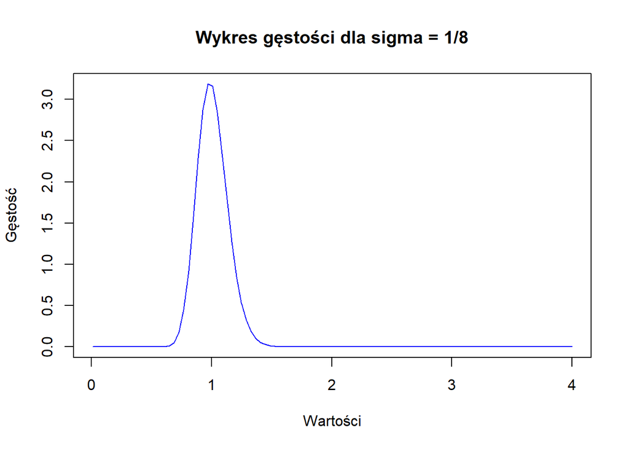

```r
dlnorm_wykres <- function(x,sigma) {
  dlnorm(x, meanlog = 0, sdlog = sigma)
}

# Tworzenie wykresu za pomocą funkcji curve
curve(dlnorm_wykres(x,1/8), from = 0.01, to = 4, col = "blue",
      xlab = "Wartości", ylab = "Gęstość",
      main = "Wykres gęstości dla sigma = 1/8")
```

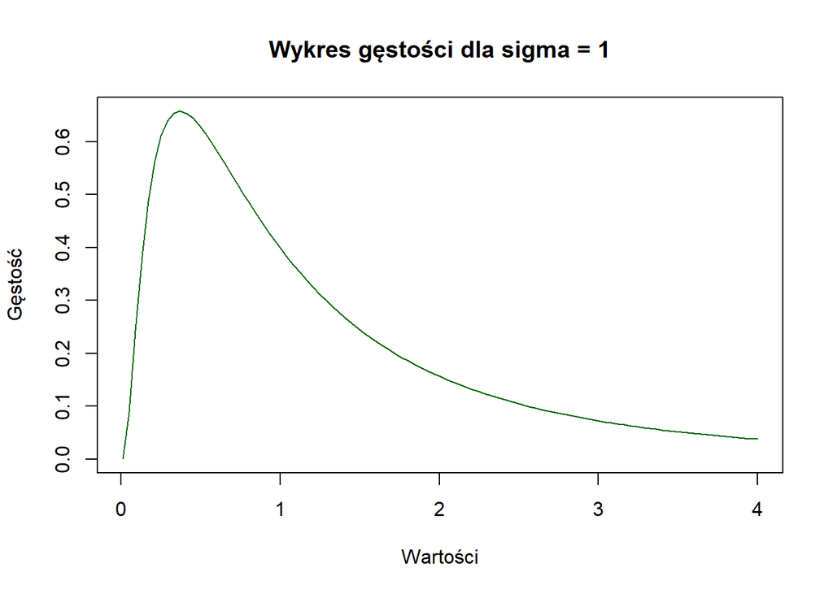

```r
curve(dlnorm_wykres(x,1), from = 0.01, to = 4, col = "darkgreen",
      xlab = "Wartości", ylab = "Gęstość",
      main = "Wykres gęstości dla sigma = 1")
```

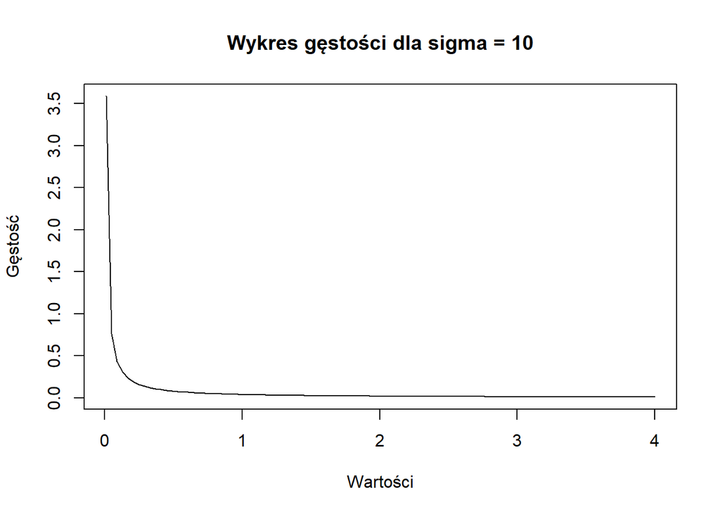

```r
curve(dlnorm_wykres(x,10), from = 0.01, to = 4, col = "black",
      xlab = "Wartości", ylab = "Gęstość",
      main = "Wykres gęstości dla sigma = 10")
```

## Tworzymy funkcję losującą wartości z rozkładu logarytmiczno-normalnego.

```r
library(moments)
data_gen <- function(k, sd){
  all_generated_data <- list()
set.seed(23)
for (i in 1:300) {
  generated_data <- rlnorm(n = k, meanlog = 0, sdlog = sd)
  all_generated_data[[i]] <- generated_data
}
srednie <- sapply(all_generated_data, mean)
srednia_srednich<-mean(srednie)
odchylenie_srednich<-sd(srednie)
skosnosc_srednich<-skewness(srednie)
kurtoza_srednich<-kurtosis(srednie)

shapiro_test <- shapiro.test(srednie) #bazowo w R jest on wykonywany dla alfa = 0.05

wyniki <- list(srednie, srednia_srednich, odchylenie_srednich, skosnosc_srednich, kurtoza_srednich, shapiro_test)

return(wyniki)

}
```

```r
wyniki1 <- data_gen(5, 1/8)

wyniki2 <- data_gen(10, 1/8)

wyniki3 <- data_gen(20, 1/8)

wyniki4 <- data_gen(30, 1/8)

wyniki5 <- data_gen(50, 1/8)

wyniki6 <- data_gen(100, 1/8)

wyniki7 <- data_gen(200, 1/8)

wyniki8 <- data_gen(500, 1/8)

wyniki9 <- data_gen(1000, 1/8)
```

# Wyniki dla parametru sigma = 1/8:

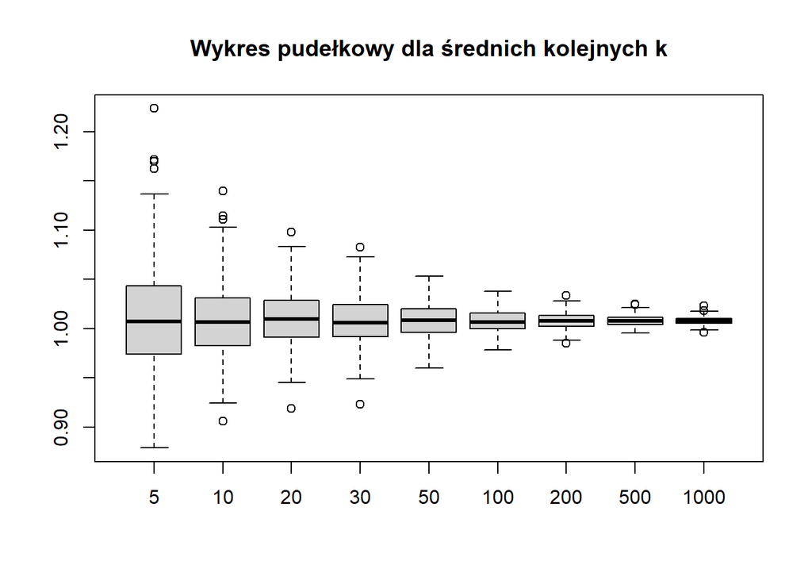

```r
boxplot(wyniki1[[1]], wyniki2[[1]], wyniki3[[1]], wyniki4[[1]], wyniki5[[1]], wyniki6[[1]], wyniki7[[1]], wyniki8[[1]], wyniki9[[1]], names = c("5", "10", "20", "30","50","100","200","500","1000"), beside = TRUE, main = "Wykres pudełkowy dla średnich kolejnych k")
```

Wraz ze wzrostem k dane są coraz bardziej skupione wokół jednej wartości.

```r
l <- c(2, 3, 4, 5)
stat <- rbind(wyniki1[l], wyniki2[l], wyniki3[l], wyniki4[l], wyniki5[l], wyniki6[l], wyniki7[l], wyniki8[l], wyniki9[l])
pval <- rbind(wyniki1[[6]]$p.value, wyniki2[[6]]$p.value, wyniki3[[6]]$p.value, wyniki4[[6]]$p.value, wyniki5[[6]]$p.value, wyniki6[[6]]$p.value, wyniki7[[6]]$p.value, wyniki8[[6]]$p.value, wyniki9[[6]]$p.value)
stat <- cbind(stat, pval)
#colnames(stat) <- c("Srednia", "Odchylenie standardowe", "Skosnosc", "Kurtoza", "P-Value")
rownames(stat) <- c("5", "10", "20", "30", "50", "100", "200", "500", "1000")
zgod<-rbind(ifelse(wyniki1[[6]]$p.value>0.05, "Zgodny","Niezgodny"),
            ifelse(wyniki2[[6]]$p.value>0.05, "Zgodny","Niezgodny"),
            ifelse(wyniki3[[6]]$p.value>0.05, "Zgodny","Niezgodny"),
            ifelse(wyniki4[[6]]$p.value>0.05, "Zgodny","Niezgodny"),
            ifelse(wyniki5[[6]]$p.value>0.05, "Zgodny","Niezgodny"),
            ifelse(wyniki6[[6]]$p.value>0.05, "Zgodny","Niezgodny"),
            ifelse(wyniki7[[6]]$p.value>0.05, "Zgodny","Niezgodny"),
            ifelse(wyniki8[[6]]$p.value>0.05, "Zgodny","Niezgodny"),
            ifelse(wyniki9[[6]]$p.value>0.05, "Zgodny","Niezgodny"))
stat<-cbind(stat, zgod)
colnames(stat) <- c("Srednia", "Odchylenie standardowe", "Skosnosc", "Kurtoza", "P-Value", "Zgodnosc")

print(stat)
```

```
##      Srednia  Odchylenie standardowe Skosnosc    Kurtoza  P-Value
## 5    1.009108 0.0559996              0.3646193   3.374152 0.02710159
## 10   1.00979  0.03824496             0.423747    3.215166 0.009616009
## 20   1.009815 0.0274571              0.1301579   3.1538   0.5200901
## 30   1.008056 0.0236503              0.07711353  3.228405 0.3982449
## 50   1.008188 0.01801259             -0.03346542 2.71492  0.7557894
## 100  1.007252 0.01203667             0.03065714  2.640179 0.2997712
## 200  1.007695 0.008347474            0.07622012  2.843407 0.9811793
## 500  1.008071 0.005504309            0.2387047   2.860252 0.2248065
## 1000 1.008014 0.004020035            0.2411952   3.358276 0.462462
##      Zgodnosc
## 5    "Niezgodny"
## 10   "Niezgodny"
## 20   "Zgodny"
## 30   "Zgodny"
## 50   "Zgodny"
## 100  "Zgodny"
## 200  "Zgodny"
## 500  "Zgodny"
## 1000 "Zgodny"
```

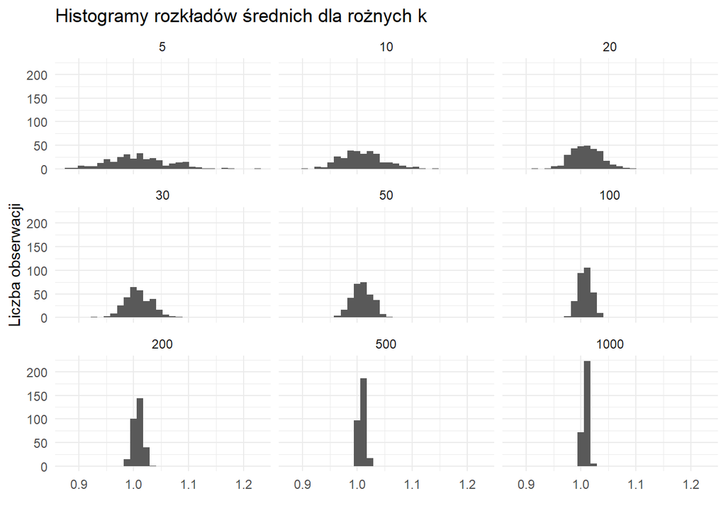

```r
df <- data.frame(
  Kolumna1 = c(rep('5', length(wyniki1[[1]])), rep('10', length(wyniki2[[1]])), rep('20',length(wyniki3[[1]])),
               rep('30', length(wyniki1[[1]])), rep('50', length(wyniki2[[1]])), rep('100',length(wyniki3[[1]])),
               rep('200', length(wyniki1[[1]])), rep('500', length(wyniki2[[1]])), rep('1000',length(wyniki3[[1]]))

               ),
  Kolumna2 = c(wyniki1[[1]], wyniki2[[1]],wyniki3[[1]],wyniki4[[1]], wyniki5[[1]],wyniki6[[1]],wyniki7[[1]], wyniki8[[1]],wyniki9[[1]])
)

df$Kolumna1 <- factor(df$Kolumna1, levels = c('5', '10', '20', '30', '50', '100', '200', '500', '1000'))
df %>%
  ggplot(aes(x=Kolumna2))+
  geom_histogram(position = "identity")+
  facet_wrap(~Kolumna1, ncol=3)+
  labs(title = "Histogramy rozkładów średnich dla rożnych k",x="",y = "Liczba obserwacji")+
  theme_minimal()
```

Wraz ze wzrostem k średnia ciągle oscyluje wokół wartości 1. Odchylenie standardowe natomiast maleje. Na podstawie testu Shapiro-Wilka możemy założyć, że dla k>=20 rozkłady średnich są zbliżone do rozkładu normalnego.

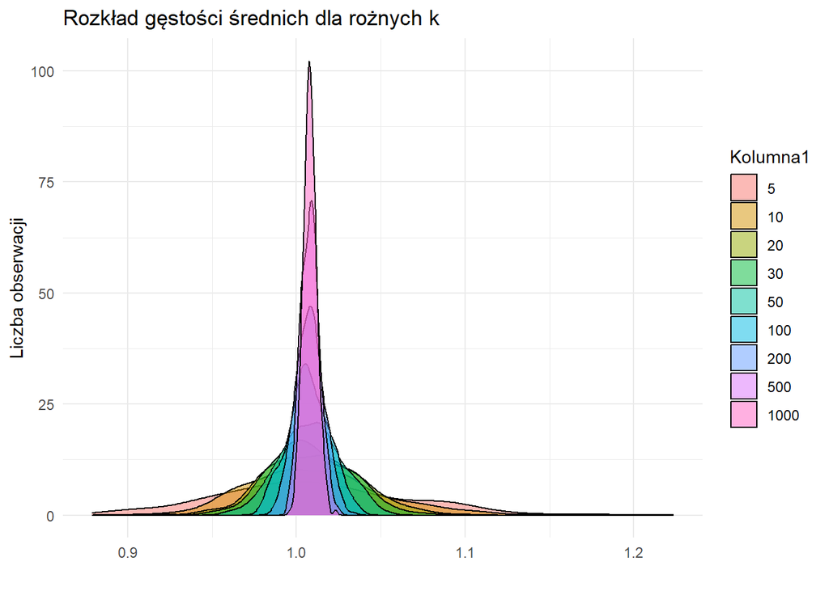

```r
df %>%
  ggplot(aes(x=Kolumna2,fill=Kolumna1 ))+
  geom_density(alpha=0.5)+
  labs(title = "Rozkład gęstości średnich dla rożnych k",x="",y = "Liczba obserwacji")+
  theme_minimal()
```

# Wyniki dla sigma = 1:

```r
wyniki1 <- data_gen(5, 1)

wyniki2 <- data_gen(10, 1)

wyniki3 <- data_gen(20, 1)

wyniki4 <- data_gen(30, 1)

wyniki5 <- data_gen(50, 1)

wyniki6 <- data_gen(100, 1)

wyniki7 <- data_gen(200, 1)

wyniki8 <- data_gen(500, 1)

wyniki9 <- data_gen(1000, 1)
```

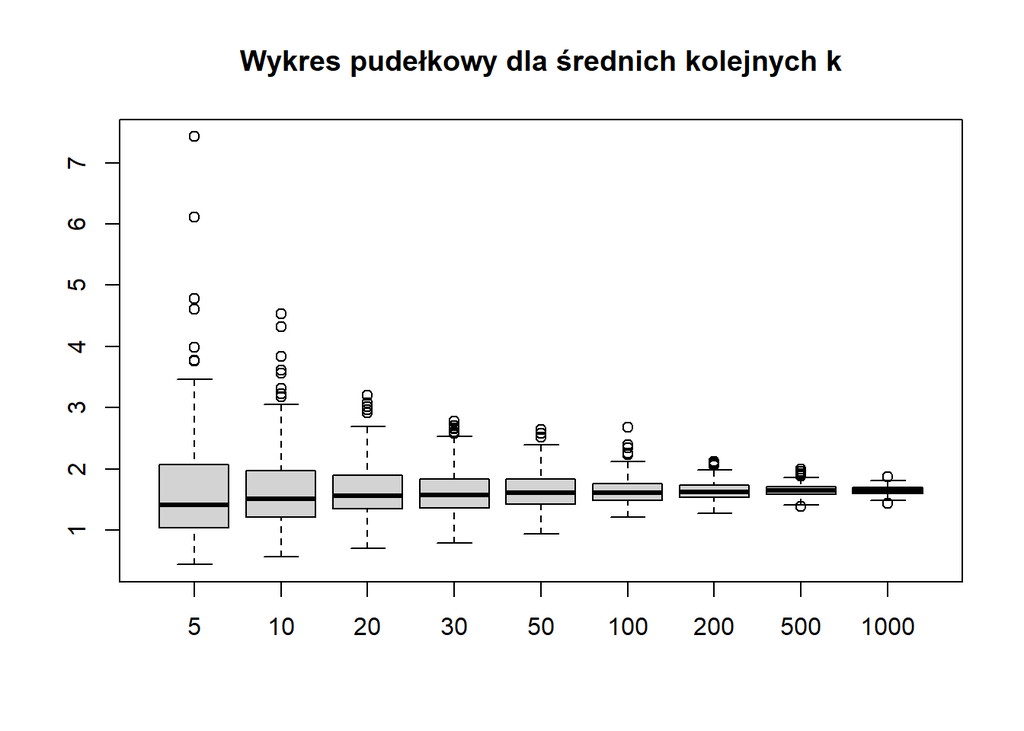

```r
boxplot(wyniki1[[1]], wyniki2[[1]], wyniki3[[1]], wyniki4[[1]], wyniki5[[1]], wyniki6[[1]], wyniki7[[1]], wyniki8[[1]], wyniki9[[1]], names = c("5", "10", "20", "30","50","100","200","500","1000"), beside = TRUE, main = "Wykres pudełkowy dla średnich kolejnych k")
```

Wraz ze wzrostem k możemy zauważyć, że wartości ponownie zaczynają oscylować wokół jednej wartości oraz lekki wzrost mediany. Ze względu na wzrost sigmy w rozkładzie logarytmiczno-normalnym widzimy znaczący wzrost rozstrzału między średnią, a wartościami odstającymi.

```
##      Srednia  Odchylenie standardowe Skosnosc  Kurtoza  P-Value
## 5    1.654993 0.8846913              1.969826  10.52125 7.014217e-16
## 10   1.655966 0.6223624              1.374477  5.709823 1.164132e-12
## 20   1.651637 0.4511147              0.8035878 3.524919 1.104419e-07
## 30   1.627702 0.3562819              0.6045731 3.280758 3.482403e-05
## 50   1.638857 0.2952242              0.5653919 3.33079  0.0002368935
## 100  1.636771 0.2156607              0.9310312 4.843461 1.015066e-07
## 200  1.645071 0.1512667              0.5012502 3.176308 0.0007289759
## 500  1.652217 0.09784578             0.3144197 3.471256 0.1048438
## 1000 1.650025 0.0689417              0.0557862 2.933076 0.9835794
##      Zgodnosc
## 5    "Niezgodny"
## 10   "Niezgodny"
## 20   "Niezgodny"
## 30   "Niezgodny"
## 50   "Niezgodny"
## 100  "Niezgodny"
## 200  "Niezgodny"
## 500  "Zgodny"
## 1000 "Zgodny"
```

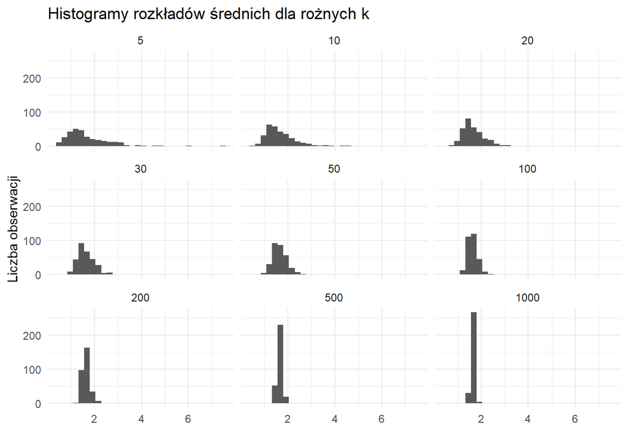

Średnia wraz ze wzrostem k nie ulega większej zmianie, w przeciwieństwie do odchylenia standardowego, które maleje, oraz skośności - która dla mniejszych k wskazuje na rozkład prawostronnie skośny, a dla większych k zamienia się na rozkład bardziej symetryczne. Wiąże się to również z wynikami Shapiro-wilka, które wykazały że tylko dla k>=500 jest zgodny z rozkładem normalnym.

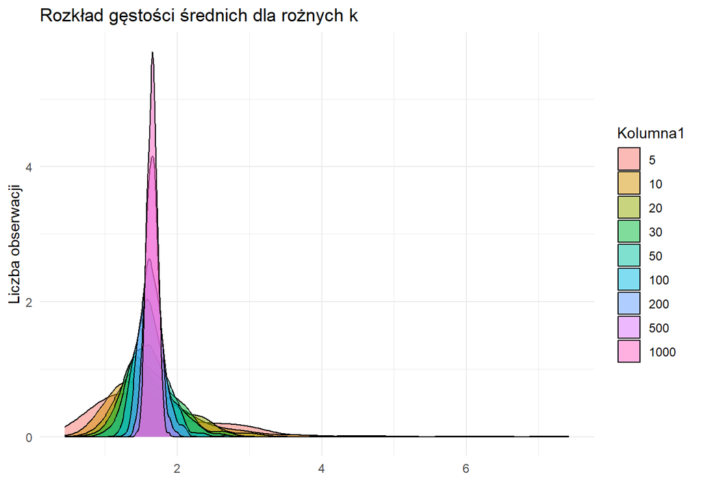

# Wyniki dla sigma = 10:

```r
wyniki1 <- data_gen(5, 10)

wyniki2 <- data_gen(10, 10)

wyniki3 <- data_gen(20, 10)

wyniki4 <- data_gen(30, 10)

wyniki5 <- data_gen(50, 10)

wyniki6 <- data_gen(100, 10)

wyniki7 <- data_gen(200, 10)

wyniki8 <- data_gen(500, 10)

wyniki9 <- data_gen(1000, 10)
```

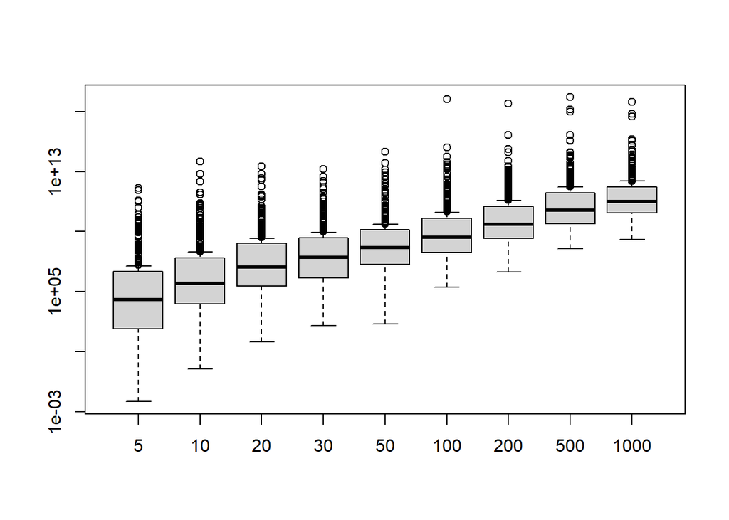

```r
boxplot(wyniki1[[1]], wyniki2[[1]], wyniki3[[1]], wyniki4[[1]], wyniki5[[1]], wyniki6[[1]], wyniki7[[1]], wyniki8[[1]], wyniki9[[1]], names = c("5", "10", "20", "30","50","100","200","500","1000"), beside = TRUE, log = "y",title="Wykres pudełkowy dla kolejnych k (skala logarytmiczna")
```

```r
#Używamy skali logarytmicznej dla lepszej wizualizacji wyników
```

Ze względu na dużą wartość parametru sigma losowane wartości mają bardzo duży rozstrzał (na co wskazuje odchylenie standardowe). Można zauważyć, że wraz ze wzrtostem k boxplot przemieszcza się wzdłuż osi Y ze względu na większe prawdopodobieństwo wylosowania wartości zawyżającej średnią całej próbki.

```
##      Srednia      Odchylenie standardowe Skosnosc Kurtoza  P-Value
## 5    5764913549   58159104131            12.22472 157.3859 1.244081e-35
## 10   186246554120 2.67149e+12            16.66072 283.7559 4.717059e-36
## 20   142017668049 1.417782e+12           14.30393 223.7364 1.29117e-35
## 30   99804129374  946460345992           14.23248 222.229  1.533243e-35
## 50   993506246319 1.200644e+13           16.31236 275.1903 6.844825e-36
## 100  2.294662e+15 3.970453e+16           17.23378 298.0031 3.33136e-36
## 200  1.159086e+15 1.985227e+16           17.23199 297.9621 3.385638e-36
## 500  3.800851e+15 5.276248e+16           16.43918 278.3426 5.077285e-36
## 1000 1.911603e+15 2.638065e+16           16.43901 278.3396 5.133329e-36
##      Zgodnosc
## 5    "Niezgodny"
## 10   "Niezgodny"
## 20   "Niezgodny"
## 30   "Niezgodny"
## 50   "Niezgodny"
## 100  "Niezgodny"
## 200  "Niezgodny"
## 500  "Niezgodny"
## 1000 "Niezgodny"
```

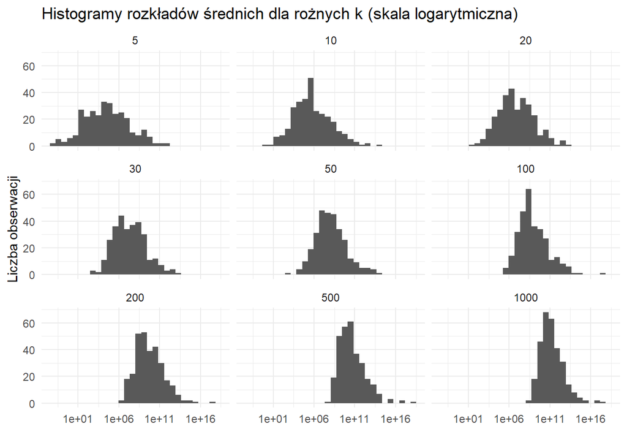

Średnia wraz ze wzrostem k znacznie rośnie, tak jak odchylenie standardowe. Żaden rozkład nie jest zgodny z rozkładem normalnym.

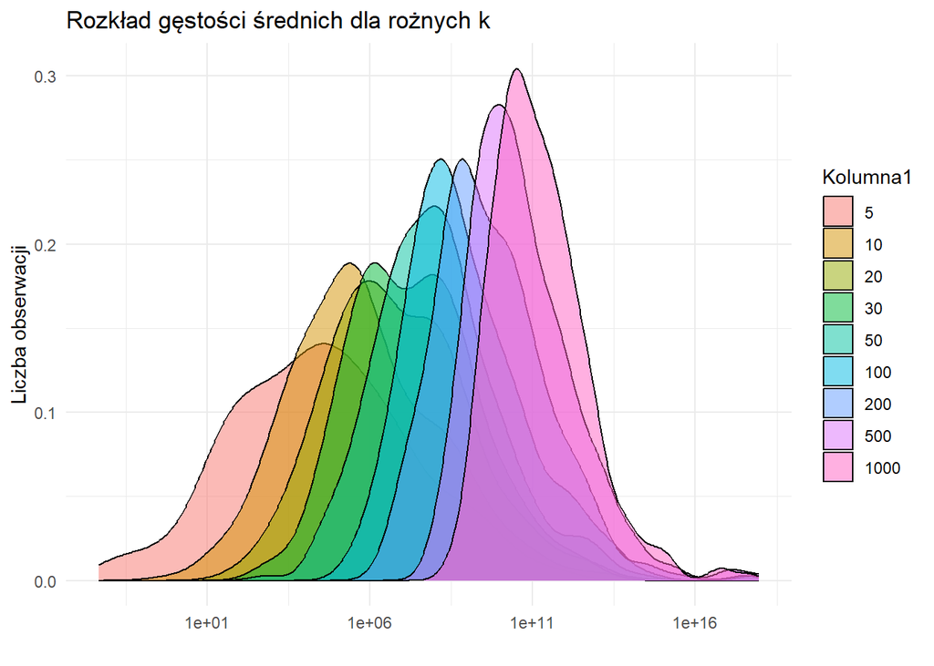

# Wariant z podnoszeniem do kwadratu

## Rozkład (losuję próbkę n = 10 000)

```r
set.seed(42)
data <- rlnorm(10000,0,1)

# Podniesienie wszystkich danych do kwadratu
data_squared <- data^2

#wartosc oczekiwana
mean(data_squared)
```

```
## [1] 7.730063
```

```r
#odchylenie standardowe
sd(data_squared)
```

```
## [1] 67.39493
```

```r
#kurtoza
kurtosis(data_squared)
```

```
## [1] 5291.225
```

```r
#skosnosc
skewness(data_squared)
```

```
## [1] 64.39969
```

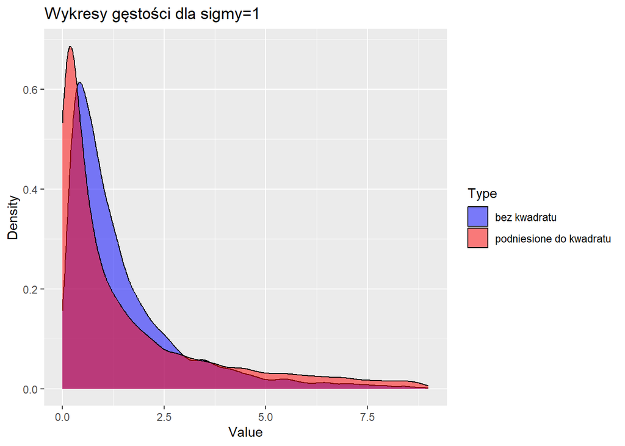

```r
df <- data.frame(Value = c(data, data_squared),
                 Type = rep(c("bez kwadratu", "podniesione do kwadratu"), each = length(data)))


ggplot(df, aes(x = Value, fill = Type)) +
  geom_density(alpha = 0.5) +
  labs(title = "Wykresy gęstości dla sigmy=1",
       x = "Value",
       y = "Density") +
      xlim(0,9)+
  scale_fill_manual(values = c("blue", "red"))
```

## Funkcję losująca wartości z rozkładu logarytmiczno-normalnego, wartości podnosimy do kwadratu.

```r
library(moments)
data_gen_square <- function(k, sd){
  all_generated_data <- list()
set.seed(23)
for (i in 1:300) {
  generated_data <- rlnorm(n = k, meanlog = 0, sdlog = sd)
  all_generated_data[[i]] <- generated_data^2
}
srednie <- sapply(all_generated_data, mean)
srednia_srednich<-mean(srednie)
odchylenie_srednich<-sd(srednie)
skosnosc_srednich<-skewness(srednie)
kurtoza_srednich<-kurtosis(srednie)

shapiro_test <- shapiro.test(srednie)

wyniki <- list(srednie, srednia_srednich, odchylenie_srednich, skosnosc_srednich, kurtoza_srednich, shapiro_test)

return(wyniki)

}
```

## Wyniki dla sigma = 1/8:

```r
wyniki1 <- data_gen_square(5, 1/8)

wyniki2 <- data_gen_square(10, 1/8)

wyniki3 <- data_gen_square(20, 1/8)

wyniki4 <- data_gen_square(30, 1/8)

wyniki5 <- data_gen_square(50, 1/8)

wyniki6 <- data_gen_square(100, 1/8)

wyniki7 <- data_gen_square(200, 1/8)

wyniki8 <- data_gen_square(500, 1/8)

wyniki9 <- data_gen_square(1000, 1/8)
```

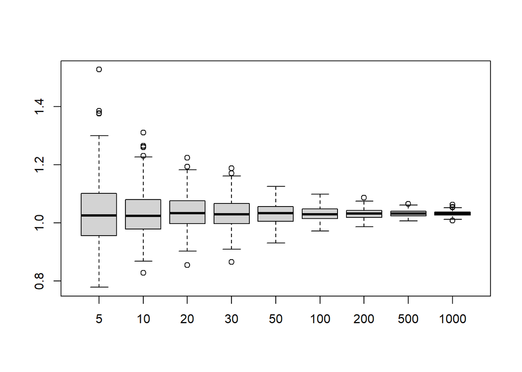

```r
boxplot(wyniki1[[1]], wyniki2[[1]], wyniki3[[1]], wyniki4[[1]], wyniki5[[1]], wyniki6[[1]], wyniki7[[1]], wyniki8[[1]], wyniki9[[1]], names = c("5", "10", "20", "30","50","100","200","500","1000"), beside = TRUE)
```

Wraz ze wzrostem k dane są coraz bardziej skupione wokół jednej wartości.

```
##      Srednia  Odchylenie standardowe Skosnosc     Kurtoza  P-Value
## 5    1.034505 0.1159246              0.5328495    3.775037 0.0006303849
## 10   1.035642 0.07913969             0.5137485    3.3482   0.001124759
## 20   1.035465 0.0570604              0.2055385    3.162034 0.253547
## 30   1.031867 0.04860423             0.1432866    3.237071 0.4480965
## 50   1.032274 0.03727525             0.0002186218 2.690167 0.770333
## 100  1.030434 0.0249981              0.09714877   2.673766 0.2410727
## 200  1.031401 0.01737824             0.1214239    2.892714 0.9316007
## 500  1.032199 0.0114709              0.2225707    2.876076 0.2462317
## 1000 1.032052 0.008357485            0.2140164    3.310029 0.6221042
##      Zgodnosc
## 5    "Niezgodny"
## 10   "Niezgodny"
## 20   "Zgodny"
## 30   "Zgodny"
## 50   "Zgodny"
## 100  "Zgodny"
## 200  "Zgodny"
## 500  "Zgodny"
## 1000 "Zgodny"
```

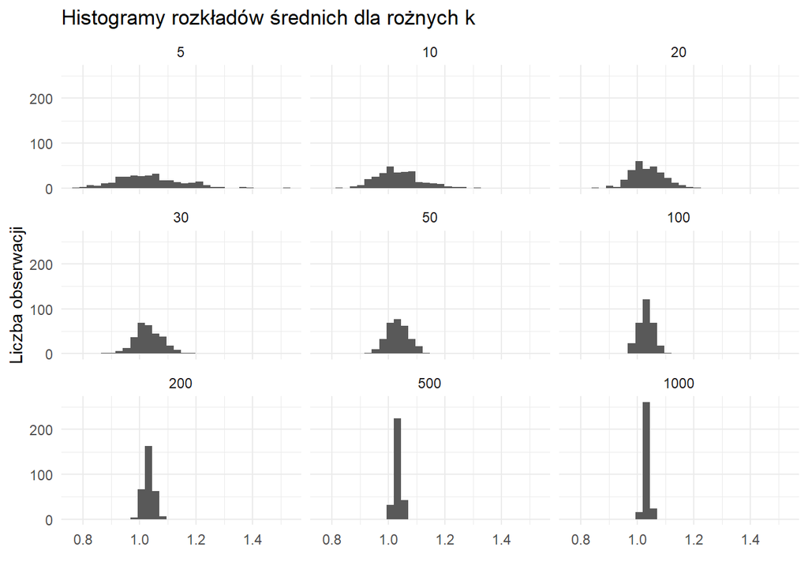

Wraz ze wzrostem k średnia ciągle oscyluje wokół wartości 1. Odchylenie standardowe natomiast maleje. Na podstawie testu Shapiro-Wilka możemy założyć, że dla k>=20 rozkłady średnich są zbliżone do rozkładu normalnego. W porównaniu do wariantu bez podnoszenia do kwadratu widzimy, że odchylenie standardowe jest większe.

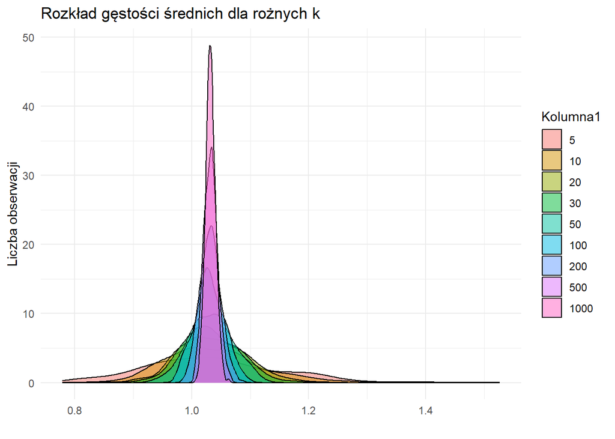

## Wyniki dla sigma = 1:

```r
wyniki1 <- data_gen_square(5, 1)

wyniki2 <- data_gen_square(10, 1)

wyniki3 <- data_gen_square(20, 1)

wyniki4 <- data_gen_square(30, 1)

wyniki5 <- data_gen_square(50, 1)

wyniki6 <- data_gen_square(100, 1)

wyniki7 <- data_gen_square(200, 1)

wyniki8 <- data_gen_square(500, 1)

wyniki9 <- data_gen_square(1000, 1)
```

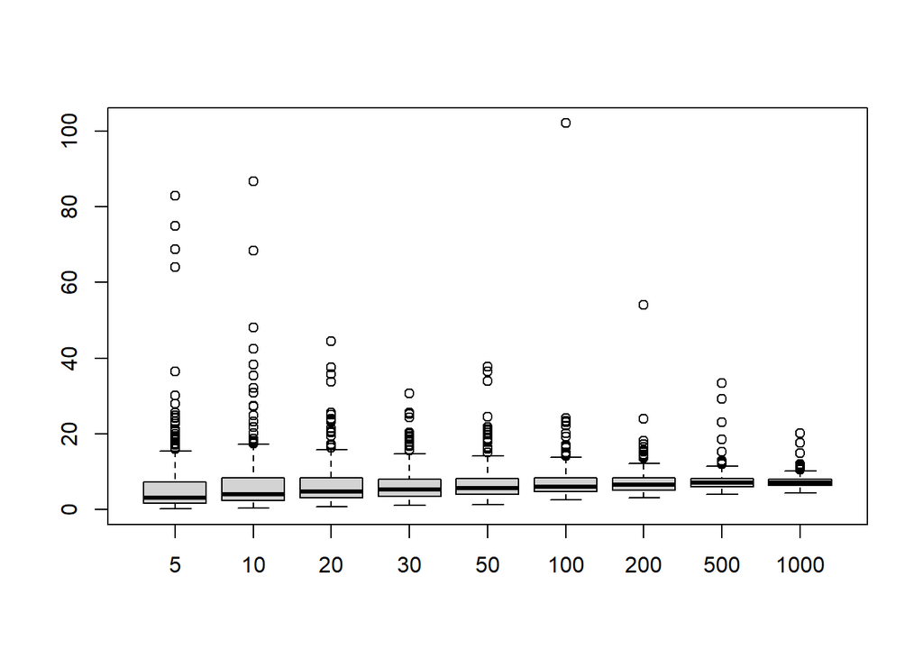

```r
boxplot(wyniki1[[1]], wyniki2[[1]], wyniki3[[1]], wyniki4[[1]], wyniki5[[1]], wyniki6[[1]], wyniki7[[1]], wyniki8[[1]], wyniki9[[1]], names = c("5", "10", "20", "30","50","100","200","500","1000"), beside = TRUE)
```

W porównianiu do wariantu bez kwadratu widzimy, że wartości odstające są dużo większe.

```
##      Srednia  Odchylenie standardowe Skosnosc Kurtoza  P-Value      Zgodnosc
## 5    6.591188 10.00948               4.392599 28.21683 4.737799e-27 "Niezgodny"
## 10   6.822056 8.850821               4.740571 34.38065 6.412538e-27 "Niezgodny"
## 20   6.847532 6.142795               2.79385  13.25454 3.603398e-22 "Niezgodny"
## 30   6.573457 4.569106               2.093088 8.542937 7.37075e-19  "Niezgodny"
## 50   6.947539 4.807491               3.042575 16.42209 6.375956e-22 "Niezgodny"
## 100  7.394691 6.581284               10.27913 144.422  2.357121e-30 "Niezgodny"
## 200  7.387062 3.881352               6.512378 73.08133 4.456579e-26 "Niezgodny"
## 500  7.542502 2.831473               4.966175 39.41251 2.739198e-25 "Niezgodny"
## 1000 7.416561 1.65739                2.984421 19.80444 3.100922e-19 "Niezgodny"
```

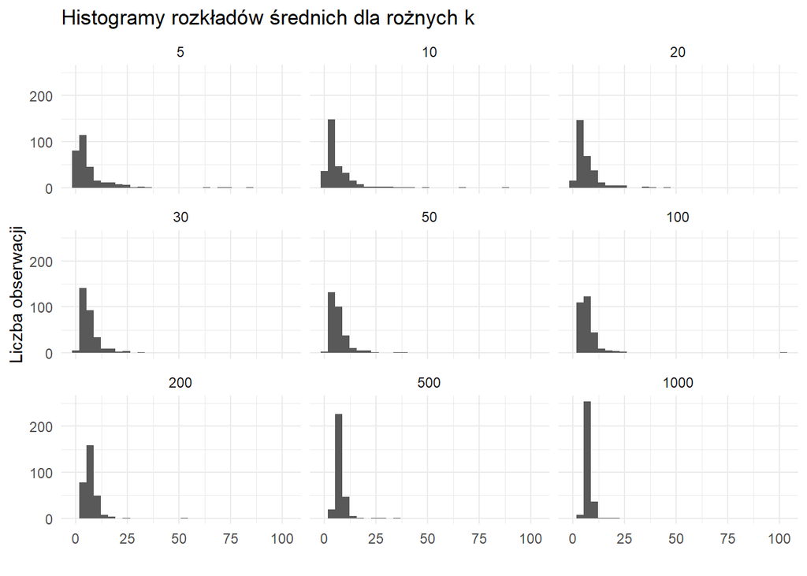

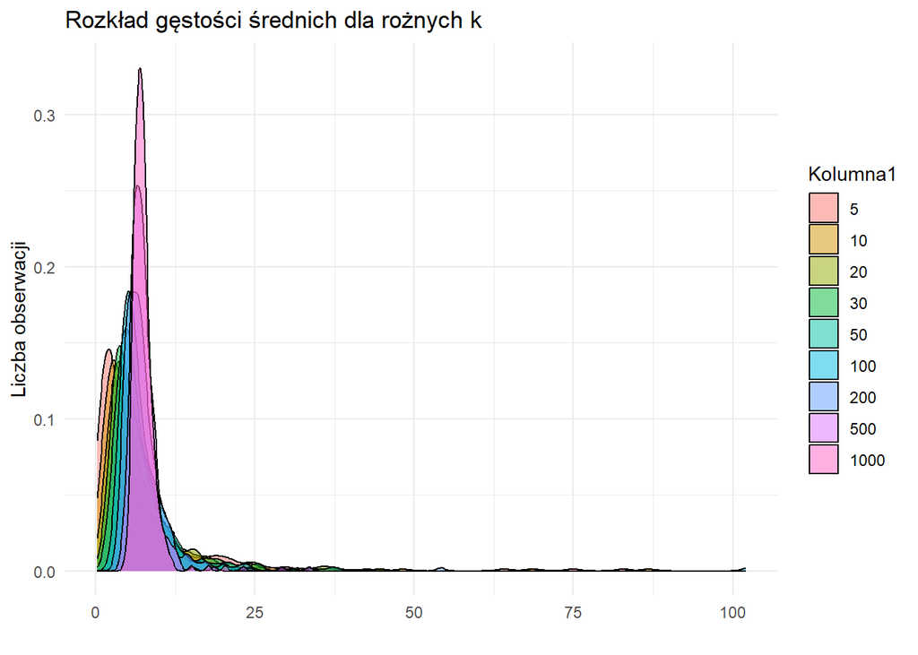

Każdy wykres jest prawnostronnie skośny, średnia wraz ze wzrostem k rośnie(w przeciwieństwie do wariantu bez kwadratu), a odchylenie standardowe maleje. Żaden rozkład nie jest zgodny z normalnym, według testu Shapiro-Wilka

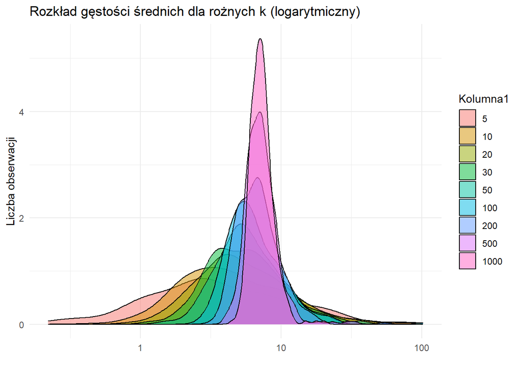

## Wyniki dla sigma = 10:

```r
wyniki1 <- data_gen_square(5, 10)

wyniki2 <- data_gen_square(10, 10)

wyniki3 <- data_gen_square(20, 10)

wyniki4 <- data_gen_square(30, 10)

wyniki5 <- data_gen_square(50, 10)

wyniki6 <- data_gen_square(100, 10)

wyniki7 <- data_gen_square(200, 10)

wyniki8 <- data_gen_square(500, 10)

wyniki9 <- data_gen_square(1000, 10)
```

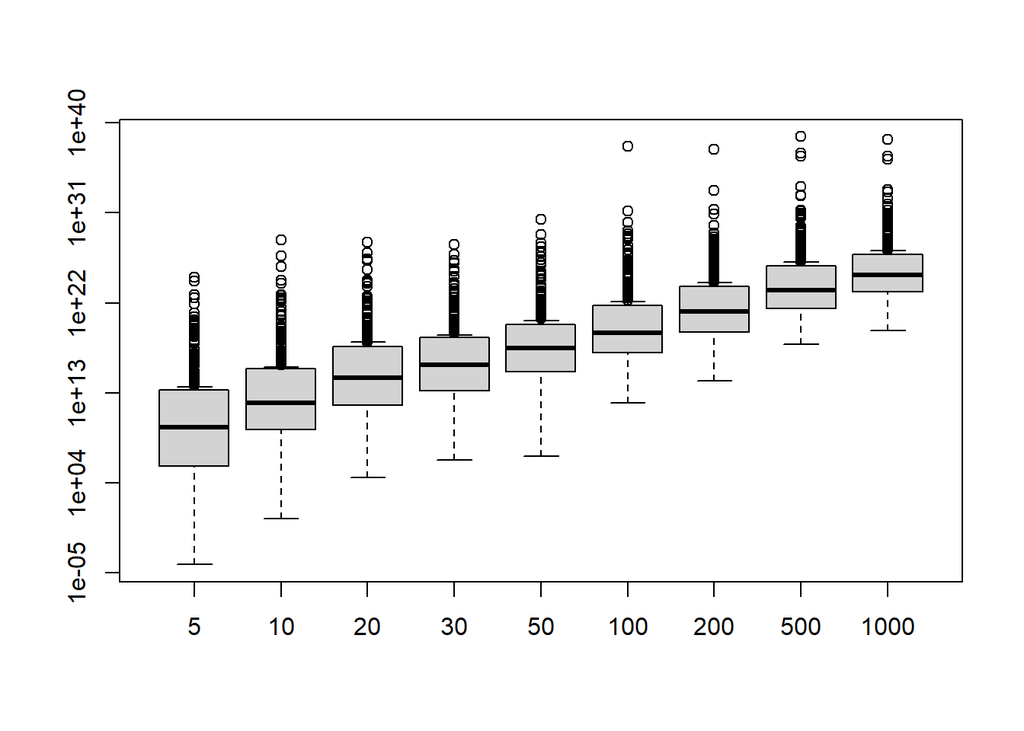

```r
boxplot(wyniki1[[1]], wyniki2[[1]], wyniki3[[1]], wyniki4[[1]], wyniki5[[1]], wyniki6[[1]], wyniki7[[1]], wyniki8[[1]], wyniki9[[1]], names = c("5", "10", "20", "30","50","100","200","500","1000"), beside = TRUE, log = "y")
```

```r
#Używamy skali logarytmicznej dla lepszej wizualizacji wyników
```

```
##      Srednia      Odchylenie standardowe Skosnosc Kurtoza  P-Value
## 5    1.692208e+22 2.144064e+23           13.92542 204.9742 6.362933e-36
## 10   7.14774e+25  1.207946e+27           17.22029 297.6896 3.464405e-36
## 20   4.04714e+25  6.067136e+26           16.97842 291.8377 4.29118e-36
## 30   2.708263e+25 4.044718e+26           16.97816 291.832  4.318257e-36
## 50   7.2223e+27   1.203224e+29           17.21064 297.4631 3.543843e-36
## 100  1.57646e+35  2.730508e+36           17.23378 298.0033 3.326283e-36
## 200  7.882844e+34 1.365254e+36           17.23378 298.0033 3.326658e-36
## 500  1.39452e+36  2.334012e+37           17.21629 297.5971 3.518165e-36
## 1000 6.972717e+35 1.167006e+37           17.21629 297.5971 3.518248e-36
##      Zgodnosc
## 5    "Niezgodny"
## 10   "Niezgodny"
## 20   "Niezgodny"
## 30   "Niezgodny"
## 50   "Niezgodny"
## 100  "Niezgodny"
## 200  "Niezgodny"
## 500  "Niezgodny"
## 1000 "Niezgodny"
```

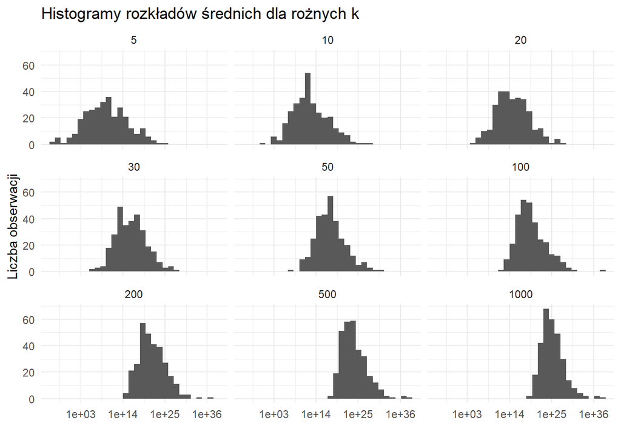

Dla sigmy 10 w wariancie podniesionym do kwadratu nie ma zbyt wielu różnic, poza tym że wartości są kwadratowo większe.

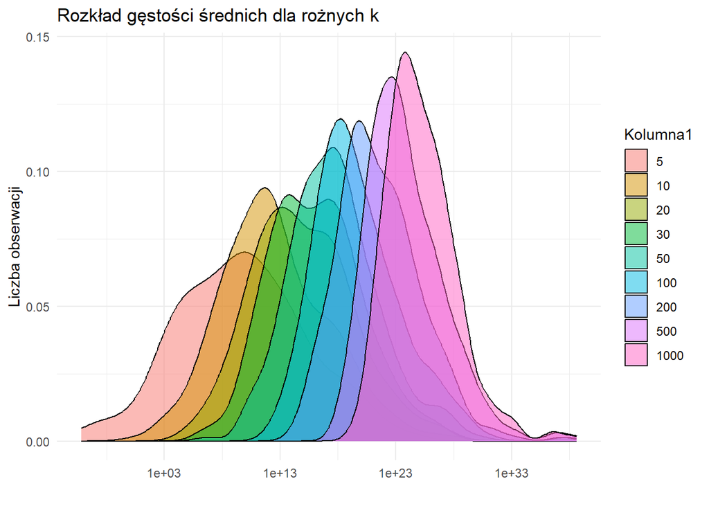

# Podsumowanie

Ze względu na własność rozkładu normalnego z wartością oczekiwaną= 0 wiemy, że na losowe wartości poniżej 0 jak i powyżej zera mamy po 50% szans wylosowania. Wynika z tego, że dla naszego rozkładu logarytmicznego-normalnego wartością krytyczną jest 1 (e^0). e o potęgach mniejszych od 0 dadzą nam wartości z przedziału (0,1), podczas gdy wykładniki>0 dadzą nam wartości z przedziału (1,+oo).

Dla σ<1, rozkład logarytmiczno-normalny charakteryzuje się większą koncentracją danych wokół średniej. Oznacza to, że zmienność danych jest mniejsza, a obserwacje są bardziej skupione wokół wartości średniej. Poszczególne wartości w danych są mniej rozproszone, co może sugerować mniejszą zmienność w badanych zjawiskach.

Gdy σ>1, rozkład logarytmiczno-normalny wykazuje większą zmienność w danych. To oznacza, że obserwacje są bardziej rozproszone wokół średniej. Wartości są bardziej odchylone od średniej, co sugeruje większą zmienność w badanych zmiennych. Warto zauważyć, że dla σ<1 rozkład ten przypomina bardziej rozkład normalny, ze względu na większą koncentrację wokół średniej. Natomiast dla σ>1 obserwacje są bardziej rozproszone, co może wskazywać na większą zmienność w danych.